# 2016 Luis F. Bacardi Award, Alwyn Gentry Awards - 2016 - Biotropica - Wiley Online Library

[Biotropica](https://onlinelibrary.wiley.com/journal/17447429)

[Volume 48, Issue 6](https://onlinelibrary.wiley.com/toc/17447429/2016/48/6) p. 933-935

[figure not shown]

Announcement

Full Access

# 2016 Luis F. Bacardi Award, Alwyn Gentry Awards

First published: 21 November 2016

https://doi.org/10.1111/btp.12400

The Association for Tropical Biology and Conservation (ATBC) recognizes the exceptional research of our students and early career scientists with awards for outstanding presentations at the ATBC's annual meeting. The *Luis F. Bacardi Award for Advances in Tropical Conservation* is awarded to the individual receiving their Ph.D. no more than 5 years before the meeting date who gives the best oral presentation. This award was established in 2005 with an endowment from the Lubee Bat Conservancy, an international non-profit organization based in Gainesville, Florida, that was founded in 1989 by the late Luis F. Bacardi and is dedicated to protecting biological diversity through the conservation of fruit- and nectar-feeding bats. The *Alwyn Gentry Presentation Awards* are in recognition of the outstanding oral and poster presentations by students at the annual meeting of the ATBC. Alwyn H. Gentry's legacy to tropical biology was not limited to the study of the diversity and conservation of tropical plants—he was a caring and supportive mentor to students from all over the Americas. The Gentry Awards are therefore in remembrance and recognition of the contributions of this singular scientist, colleague, mentor, and friend. On behalf of the ATBC, we would like to thank the early-career scientists that presented their work at the 2016 ATBC Meeting in Montpellier, extend our gratitude to the many meeting delegates who served as judges, and congratulate the following recipients for their outstanding presentations.

**Kyle Harms,** Louisiana State University; and **Julieta Benítez-Malvido,** Universidad Nacional Autonoma de México. *Bacardi and Gentry Award Co-Chairs*

**Emilio M. Bruna,** University of Florida, *Editor-in-Chief,* Biotropica

## The 2016 Luis F. Bacardi Award for Advances in Tropical Conservation

**Oliver Wearn: Multi-species modeling using camera traps: challenges and opportunities.** Oliver Wearn<sup>1</sup>, Marcus Rowcliffe<sup>1</sup>, Chris Carbone<sup>1</sup>, Marion Pfeifer<sup>2</sup>, Henry Bernard<sup>3</sup>, Robert Ewers<sup>4</sup>; *<sup>1</sup>Zoological Society of London, UK, <sup>2</sup>Imperial College London, UK, <sup>3</sup>Universiti Malaysia Sabah, Malaysia, <sup>4</sup>Imperial College London, UK*.

The camera trap is now a familiar tool for wildlife biologists across the globe, operating in all terrestrial environments and catching a wide variety of warm-blooded species. Until recently, though, most camera surveys have routinely discarded wildlife. ‘By-catch’ species, typically those that do not have stripes or spots, may be ‘thrown back’ either at the image cataloguing or analysis stage. New statistical tools, however, increasingly allow for robust inferences to be made about such species. In this talk, I consider a ban on discards. I will discuss the opportunities, and challenges, of hierarchical multi-species modeling of whole communities, with reference to a large dataset collected on the island of Borneo. We deployed cameras and live traps over the course of three years in a clustered design, to assess mammalian community structure across a gradient of land-use intensity (primary forest, logged forest, and oil palm plantations). This allowed us to simultaneously monitor ~60 species of large and small mammal across the gradient, and begin to explore how the coarse- and fine-scale structure of terrestrial mammal communities is altered by changes in land-use. At the coarse community scale, we found a remarkable overall resilience to selective logging, but fine-scale dissection of the community highlighted particular groups (*e.g*., frugivores) and particular species (*e.g*., the banded civet, Hemigalus derbyanus) which do not respond favorably. Oil palm, on the other hand, exhibited a severely depauperate mammal community, with only a handful of species (some carnivores, and invasives) prospering. Hierarchical multi-species modeling was analytically and computationally intensive, but ultimately allowed for a more comprehensive understanding of community responses.

[figure not shown]

Oliver Wearn, Recipient of the **2016 Luis F. Bacardi Award for Advances in Tropical Conservation**

## 2016 Alwyn Gentry Award for best Poster Presentation

**Adriane Esquivel Muelbert: Large-scale Neotropical genera distributions predict drought-induced mortality of trees.** Adriane Esquivel Muelbert<sup>1</sup>, Timothy Baker<sup>1</sup>, Kyle Dexter<sup>2</sup>, Simon Lewis<sup>1</sup>, David Galbraith<sup>1</sup>, Hans Ter Steege<sup>3</sup>, Patrick Meir<sup>4</sup>, Lucy Rowland<sup>2</sup>, Gabriela Lopez-Gonzalez<sup>1</sup>, Oliver Phillips<sup>1</sup>; *<sup>1</sup>University of Leeds, UK, <sup>2</sup>The University of Edinburgh, UK, <sup>3</sup>Naturalis Biodiversity Center, The Netherlands, <sup>4</sup>Australian National University, Australia*.

Droughts are an increasing threat for tropical rain forests, with impacts to forest biodiversity and ecosystem services, including carbon storage. Within the tropics, tree species richness is positively associated with precipitation, which is likely to be a consequence of water-stress constraining important physiological processes of most taxa. If so, macroecological distributions of tropical taxa would provide valuable insights about the potential impacts of droughts on Neotropical diversity. Methods: We combine data from 531 inventory plots of closed canopy forest across the Western Neotropics to investigate how water-deficit influences the distribution of tropical tree genera. For that, we firstly calculated genera ‘water deficit affiliation’ (WDA), which represents the mean of taxa distributions along the water-deficit gradient weighted by their abundance. Secondly, we tested the ability of WDA to predict drought-induced mortality at one natural and four experimental droughts across the Neotropics. Results: Drought tolerant genera tend to be disproportionally widespread across the precipitation gradient, reaching even the wettest climates sampled. However, most genera are restricted to wet areas. Macroecological distributions did predict drought resistance, with wet-affiliated genera tending to show higher drought-induced mortality regardless of their life history stage and after accounting for the influence of phylogeny. Discussion: The large-scale distributional patterns of genera with respect to climate have predictive value for their vulnerability to water-stress. It is the first time this question has been assessed at a macroecological scale for the tropics. Our results suggest that the anticipated increase in extreme dry events for this region may threaten biodiversity, given that the majority of Neotropical taxa are wet-affiliated and that most of these have relatively small ranges. Overall, this study establishes a baseline for exploring how floristic composition of tropical forests may shift in response to current and future environmental changes in this region.

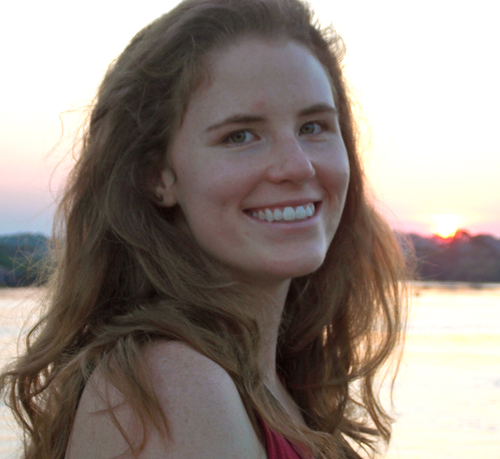

Adriane Esquivel Muelbert, recipient of the **2016 Alwyn Gentry Award for Best Poster Presentation**

## The 2016 Alwyn Gentry Award for Best Poster Presentation

**William Farfan-Rios: Community patterns of wood density along an Andes-to-Amazon gradient.** William Farfan-Rios<sup>1</sup>, Miles R. Silman<sup>1</sup>, Imma Oliveras<sup>2</sup>, Yadvinder Malhi<sup>2</sup>, Alex Nina<sup>3</sup>; *<sup>1</sup>Wake Forest University, USA, <sup>2</sup>Oxford University, UK, <sup>3</sup>Universidad Nacional de San Antonio Abad del Cusco, Peru*.

Major changes in forest diversity, plant species composition and functional diversity occur along environmental gradients, and the Andes-to-Amazon gradient is Earth's longest and highest biodiversity forest gradient. Wood density is an important functional trait related to wood properties and carbon accumulation. The few studies of this trait across altitudinal gradients have shown a decrease with increasing elevation, though this trend is still unclear in the tropics. We (1) tested the effects of elevation on interspecific variation and stand-level wood density across 3.5 km altitudinal gradient; and (2) looked at the intraspecific variation across the gradient. Methods: More than 891 tree core samples were taken for 314 taxa at 59 sites across a 3.5 km altitudinal transect running from Andean tree line to Amazonian lowlands in Peru. We used data from 16 1-ha permanents plots (ABERG network) across the gradient to test the effects of elevation in wood density weighted by number of individuals (NI) and basal area (BA). Results: Results showed a positive relationship of wood density with elevation and this trend is even stronger when wood density was weighted by NI, BA. We observed an abrupt transition in wood density at ~1500 m in the cloud base zone. The intraspecific relationship between elevation and wood density differ greatly among species, with taxa showing increasing, decreasing, and no response to elevation. Discussion and/or conclusion: Turnover in species composition had a direct effect on stand-level wood density and showed a strong relationship with elevation. These results for Andean and Amazonian systems have implications in forest biomass calculations and in general understanding of ecosystem function.

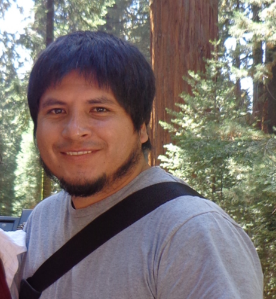

William Farfan-Rios, recipient of the **2016 Alwyn Gentry Award for Best Poster Presentation**

**Mar Cartró-Sabaté: Identifying sources of lead in Amazonian wildlife by lead isotope analysis.** Mar Cartró-Sabaté<sup>1</sup>, Pedro Mayor Aparicio<sup>2</sup>, Antoni Rosell-Melé<sup>3</sup>, Martí Orta-Martínez<sup>4</sup>; <sup>*1*</sup>*Institut de Ciència i Tecnologia Ambientals, Spain,* <sup>*2*</sup>*Dept. Sanitat i Anatomia Animals, Spain,* <sup>*3*</sup>*Institució Catalana de Recerca i Estudis Avançats, Spain,* <sup>*4*</sup>*International Institute of Social Studies, The Netherlands*

The first barrels of oil extracted from the northern Peruvian Amazon were obtained in the early 1970s. Hydrocarbon concessions have been spread across the territory, and 70 percent of the Peruvian tropical rain forests have been leased at some point between 1970- 2009. Although there is a dearth of scientific studies, a number of governmental studies have been shown a bothering presence of heavy metals and hydrocarbons in the physical environment and human communities in the area. According to the indigenous inhabitants of the oil concession, game species frequently visit oil spills to ingest oil-polluted soil. Our hypothesis is that game species frequent these sites attracted by salts that usually accompanied oil spills. Some heavy metals and polycyclic aromatic hydrocarbons usually found in these dumping sites are persistent and toxic and may climb through the food chain affecting the whole ecosystem and the local human populations that rely on subsistence hunting. We have already collected visual evidences of this phenomenon through a camera trap program. This paper presents our results on the assimilation and bioaccumulation of oil contaminants by game species in the study area. We have conducted heavy metals analysis of soil samples and of game animal livers collected in the study area, as well as in control areas that have never been affected by hydrocarbon activities. A lead isotopic fingerprint analysis shows that control liver samples share the same sole source of lead that we assume to be lead naturally present in soils. Livers samples from the oil concession also have another source of lead: oil spills are a relevant contributor of lead in the livers of game species inside the oil concession. Taking into account that up to 30 percent of the world's rain forests overlap with hydrocarbon reserves our results may be very relevant to evaluate the impacts of the oil industry on wildlife and public health for the whole Amazon and beyond.

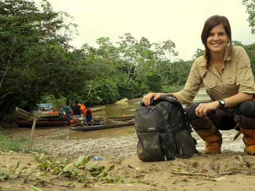

[figure not shown]

[Volume48, Issue6](https://onlinelibrary.wiley.com/toc/17447429/2016/48/6)

November 2016

Pages 933-935